# ces() - Complex Exponential Smoothing

Ivan Svetunkov

2016-09-16

This vignette covers `ces()` and `auto.ces()` functions, which are part of smooth package. In this vignette we will use data from `Mcomp` package, so it is adviced to install it.

Let’s load the necessary packages:

```r
require(smooth)
require(Mcomp)
```

`ces()` function allows constructing Complex Exponential Smoothing either with no seasonality, or with simple / partial / full seasonality. A simple call for `ces()` results in estimation of non-seasonal model:

For the same series from M3 dataset `ces()` can be constructed using:

```r
ces(M3$N2457$x, h=18, holdout=TRUE)
```

```
## Time elapsed: 0.17 seconds
## Model estimated: CES(n)
## a0 + ia1: 1.10852+1.01143i
## Initial values were produced using backcasting.
## 3 parameters were estimated in the process
## Residuals standard deviation: 1419.223
## Cost function type: MSE; Cost function value: 1951899
##
## Information criteria:
##      AIC     AICc      BIC
## 1686.252 1686.511 1693.977
##
## Forecast errors:
## MPE: 15.7%; Bias: 76.3%; MAPE: 37.3%; SMAPE: 42.7%
## MASE: 2.635; sMAE: 107.5%; RelMAE: 1.126; sMSE: 204.4%
```

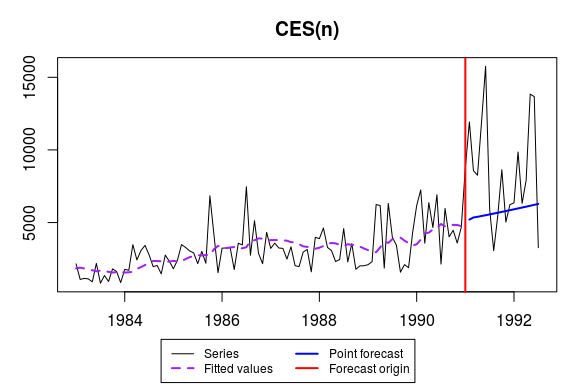

This output is very similar to ones printed out by `es()` function. The only difference is complex smoothing parameter values which are printed out instead of persistence vector in `es()`.

If we want automatic model selection, then we use `auto.ces()` function:

```r
auto.ces(M3$N2457$x, h=18, holdout=TRUE, intervals=TRUE)
```

```
## Estimating CES with seasonality: "none" "simple" "partial" "full"
## The best model is with seasonality = "partial"
```

```
## Time elapsed: 1.15 seconds
## Model estimated: CES(p)
## a0 + ia1: 1.12697+1.01336i
## b: 0
## Initial values were produced using backcasting.
## 4 parameters were estimated in the process
## Residuals standard deviation: 1345.689
## Cost function type: MSE; Cost function value: 1736204
##
## Information criteria:
##      AIC     AICc      BIC
## 1676.894 1677.328 1687.192
##
## 95% parametric prediction intervals were constructed
## 61% of values are in the prediction interval
## Forecast errors:
## MPE: 10.2%; Bias: 67.1%; MAPE: 33.7%; SMAPE: 36.7%
## MASE: 2.333; sMAE: 95.2%; RelMAE: 0.997; sMSE: 168.7%
```

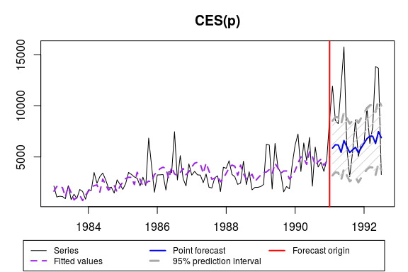

Note that prediction intervals are too narrow and do not include 95% of values. This is because CES is pure additive model and it cannot take into account possible heteroscedasticity.

If for some reason we want to optimise initial values then we call:

```r
auto.ces(M3$N2457$x, h=18, holdout=TRUE, initial="o", intervals=TRUE, intervalsType="s")
```

```
## Estimating CES with seasonality: "none" "simple" "partial" "full"
## The best model is with seasonality = "none"
```

```
## Time elapsed: 1.05 seconds
## Model estimated: CES(n)
## a0 + ia1: 1.09841+1.01221i
## Initial values were optimised.
## 5 parameters were estimated in the process
## Residuals standard deviation: 1430.254
## Cost function type: MSE; Cost function value: 1940181
##
## Information criteria:
##      AIC     AICc      BIC
## 1689.668 1690.328 1702.542
##
## 95% semiparametric prediction intervals were constructed
## 61% of values are in the prediction interval
## Forecast errors:
## MPE: 15.2%; Bias: 75.7%; MAPE: 37.3%; SMAPE: 42.5%
## MASE: 2.622; sMAE: 107%; RelMAE: 1.12; sMSE: 202.9%
```

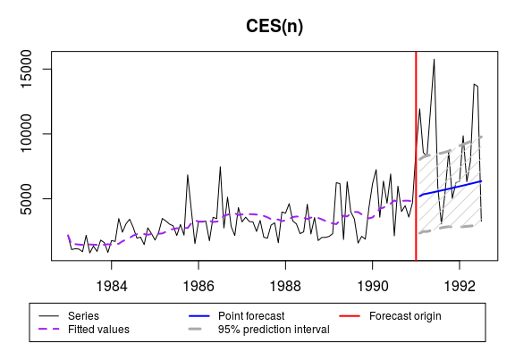

Now let’s introduce some artificial exogenous variables:

```r
x <- cbind(rnorm(length(M3$N2457$x),50,3),rnorm(length(M3$N2457$x),100,7))
```

`ces()` allows using exogenous variables and different types of prediction intervals in exactly the same manner as `es()`:

```r
auto.ces(M3$N2457$x, h=18, holdout=TRUE, xreg=x, intervals=TRUE)
```

```
## Estimating CES with seasonality: "none" "simple" "partial" "full"
## The best model is with seasonality = "partial"
```

```
## Time elapsed: 2.16 seconds
## Model estimated: CES(p)
## a0 + ia1: 1.20808+1i
## b: 0.00759
## Initial values were produced using backcasting.
## 6 parameters were estimated in the process
## Residuals standard deviation: 1376.988
## Xreg coefficients were estimated in a normal style
## Cost function type: MSE; Cost function value: 1778810
##
## Information criteria:
##      AIC     AICc      BIC
## 1683.245 1684.179 1698.694
##
## 95% parametric prediction intervals were constructed
## 61% of values are in the prediction interval
## Forecast errors:
## MPE: 19.6%; Bias: 85.6%; MAPE: 34.9%; SMAPE: 41%
## MASE: 2.543; sMAE: 103.8%; RelMAE: 1.086; sMSE: 192.2%
```

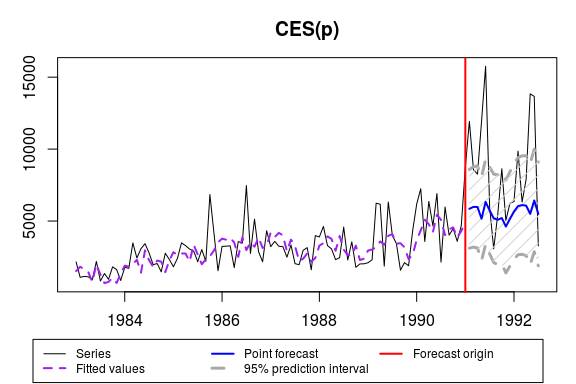

The same model but with updated parameters of exogenous variables is called:

```r
auto.ces(M3$N2457$x, h=18, holdout=TRUE, xreg=x, updateX=TRUE, intervals=TRUE)
```

```
## Estimating CES with seasonality: "none" "simple" "partial" "full"
## The best model is with seasonality = "partial"
```

```
## Time elapsed: 2.19 seconds
## Model estimated: CES(p)
## a0 + ia1: 1.20808+1i
## b: 0.00759
## Initial values were produced using backcasting.
## 6 parameters were estimated in the process
## Residuals standard deviation: 1376.988
## Xreg coefficients were estimated in a normal style
## Cost function type: MSE; Cost function value: 1778810
##
## Information criteria:
##      AIC     AICc      BIC
## 1683.245 1684.179 1698.694
##
## 95% parametric prediction intervals were constructed
## 61% of values are in the prediction interval
## Forecast errors:
## MPE: 19.6%; Bias: 85.6%; MAPE: 34.9%; SMAPE: 41%
## MASE: 2.543; sMAE: 103.8%; RelMAE: 1.086; sMSE: 192.2%
```

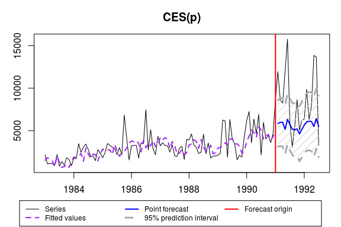